# 数据集清洗

邱飞

万里学院

## 数据清洗：纠正或去除不正确的数据

- 在前面一讲的数据集分组计算和筛选部分，我们发现上证google finance的上证指数有几处错误。
- 于是我们会想，只是上证指数的数据有错吗？其他数据有没有错？

## 显然，我们需要一种系统的方式

- 所谓系统的方式，就是批量整体操作的快捷方式
- 能用什么方法快速发现错误呢？
- 我们想到，上一将辛苦计算得到的每只股票的日收益率数据似乎还没有用过。

## 清洗

```r
library(dplyr)
return_clean = filter(return,return>=-0.11 & return <= 1)
```

## 看一下我们清洗的成果

```r
#清洗前的记录数
(number_before = nrow(return))
```

```
## [1] 1014928
```

```r
#清洗后的记录数
(number_after = nrow(return_clean))
```

```
## [1] 1012033
```

```r
#被清洗掉的数据条数
number_kill = number_before - number_after

number_kill
```

```
## [1] 2895
```

数据清洗前，一共有1014928条数据，数据清洗后，一共有1012033条数据，总共清洗了2895条数据。

## 用清洗过后的数据直接画图

- 看看与之前我们逐步清洗出来的结果是否一致

```r
hushen = filter(return_clean,
                 code == "SHA000001" | code == "SHE399001")
library(ggplot2)
hushen_plot = ggplot(hushen,
                    aes(x = date, y = return,color = code))+
                    geom_line()
```

## show plot

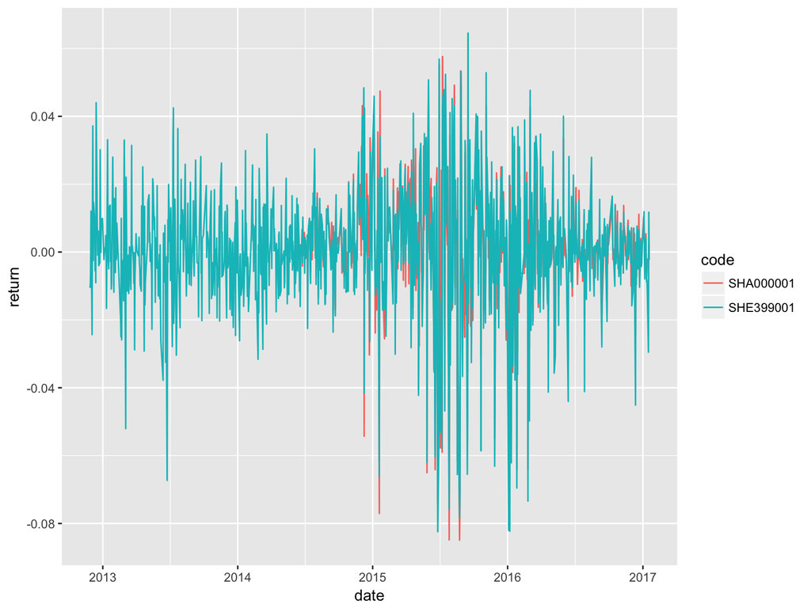

## 对股票数据集进行清洗

- 既然return数据集中有错误的数据
- 而return数据集又是从stock数据集计算得到的
- 那么着说明stock数据集中也有错误的数据存在

## 于是，以收益率数据集为条件，对股票数据集进行清洗

- stock和return都有code和date列
- return清洗的过程是去掉一些不符合条件的记录，也就是说它的date的范围会变小
- 于是我们可以用return里面的date的取值来替代stock里面的date，这样就起到了**近似**对stock清洗的效果。

## 清洗股票数据集

- 使用`dplyr`里的`inner_join`函数来合并stock和清洗后的return数据集。
- `inner_join`函数`by`后面的参数是合并的参照变量

```r
stock_grouped = group_by(stock,code)

stock_clean = inner_join(stock_grouped,return_clean,
                         by = c("code","date"))
```

## 保存清洗过后的股票数据集

```r
save(stock_clean,file = "stock_clean.rda")
```

- 至此，本讲的数据清洗部分完成了。后续我们分析的数据集将是`stock_clean`。

## 一个问题

- 为什么我在之前说这的清洗方法是对stock的**近似**清洗？

## 总结

- 免费的公开数据有很多错误，所以在使用时要特别注意。
- 数据清洗和数据预处理都是十分费时的准备工作，所以在实战中，一般都购买处理好了的商业数据。